# Biostatistical Methods II Homework 10

Arghya Kannadaguli (ak5357)

2025-04-13

**The following survival data are collected with the time unit in years and + indicating right censoring.**

$$1.2+, 4.3, 5.0, 5.0+, 6.1.$$

**(a) Obtain the Kaplan-Meier estimator of the survival function S(t).**

First let’s put the data into a tibble.

```r
# Pull survival data into a tibble
dat = tibble(
  t.i = c(1.2, 4.3, 5.0, 5.0, 6.1),
  delta = c(0, 1, 1, 0, 1)
)

# Check that data has been entered correctly
s.dat = Surv(time = dat$t.i, event = dat$delta)
s.dat
```

```
## [1] 1.2+ 4.3  5.0  5.0+ 6.1
```

Let’s create the Kaplan-Meier table.

```r
km.table = dat |>
  group_by(t.i) |>
  summarize(d.i = sum(delta), .groups = "drop") |> # deaths for each t.i
  mutate(n.i = sapply(t.i, function(t) sum(dat$t.i >= t))) |> # number at risk
  filter(d.i > 0) |> # filter only death times
  mutate(
    csp = 1 - (d.i / n.i), # conditional survival probability at t.i
    survival = cumprod(1 - (d.i / n.i))) # cumulative product of csp

km.table |>
  knitr::kable(digits = 3)
```

| t.i | d.i | n.i | csp | survival |
| --- | --- | --- | --- | --- |
| 4.3 | 1 | 4 | 0.750 | 0.75 |
| 5.0 | 1 | 3 | 0.667 | 0.50 |
| 6.1 | 1 | 1 | 0.000 | 0.00 |

Next let’s fit the Kaplan-Meier survival function.

```r
km = survfit(s.dat~1, conf.type = "log")
summary(km)
```

```
## Call: survfit(formula = s.dat ~ 1, conf.type = "log")
##
##  time n.risk n.event survival std.err lower 95% CI upper 95% CI
##   4.3      4       1     0.75   0.217        0.426            1
##   5.0      3       1     0.50   0.250        0.188            1
##   6.1      1       1     0.00     NaN           NA           NA
```

**(b) With the above estimator, sketch the Kaplan-Meier curve.**

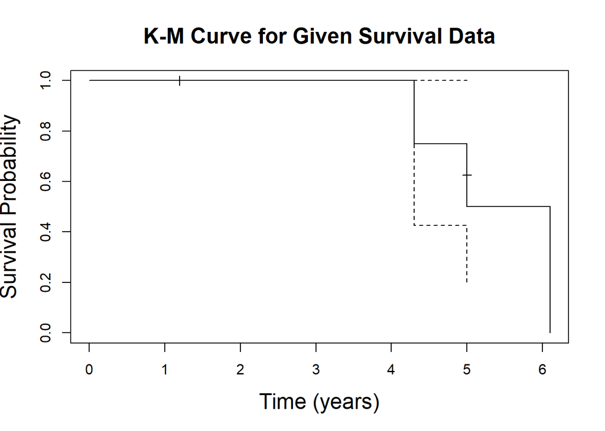

```r
plot(km, mark.time = TRUE,
     xlab="Time (years)", ylab="Survival Probability", main="K-M Curve for Given Survival Data",
     cex.lab=1.5, cex.main=1.5)
```

**(c) What is the median survival rate?**

According to the output below, the median survival time is 5.55 years.

```r
km
```

```
## Call: survfit(formula = s.dat ~ 1, conf.type = "log")
##
##      n events median 0.95LCL 0.95UCL
## [1,] 5      3   5.55     4.3      NA
```

```r
summary(km)
```

```
## Call: survfit(formula = s.dat ~ 1, conf.type = "log")
##
##  time n.risk n.event survival std.err lower 95% CI upper 95% CI
##   4.3      4       1     0.75   0.217        0.426            1
##   5.0      3       1     0.50   0.250        0.188            1
##   6.1      1       1     0.00     NaN           NA           NA
```

So my final answer is that **the median is 5.0 years**.

**(d) Give an estimate of the probability of survival at 5.5 years. Provide its 95% confidence interval.**

**Interpret both the estimate and the 95% CI. You may refer to the following output from R.**

`Call: survfit(formula = Surv(time, dead) ~ 1)` `time n.risk n.event survival std.err lower 95% CI upper 95% CI` `5.5 1 2 0.5 0.25 0.188 1`

According to the Kaplan-Meier survival fit produced, the estimated probability that an individual survives past 5.5 years is 50%, with a 95% confidence interval of 18.8% to 100%. Because the confidence interval includes 1 (or 100%) this tells us that our estimate is uncertain likely due to there being few individuals at risk at 5.5 years.